# Communicate Data Findings: Ford Gobike System Data

## by Bakut S Bonat

## Investigation Overview

> This process includes collection of data from the link provided by udacity as a prerequisite for graduating Data Analyst Nano-degree from https://s3.amazonaws.com/fordgobike-data/index.html and exploration of the data. the goal for this process is to;
1. what is the duration seconds for trips?
2. Does the above depend on if the user is a subscriber or customer?
3. who should be our target customers? in terms of advertising, who are our target audience?

## Dataset Overview

> The Ford Gobike system data was designed with the following specification in mind:

```
*Provide the status of the system at this moment.
*Do not provide information whose primary purpose is historical.
```

Historical data, including station details and ride data is to be provided by a more compact specification designed specifically for such archival purposes. The data in the specification contained in this document is intended for consumption by clients intending to provide real-time (or semi-real-time) transit advice and is designed as such.

Each trip is anonymized and includes: Trip Duration, Start Time and Date, End Time and Date, Start Station ID, Start Station Name, Start Station Latitude,Start Station Longitude, End Station ID, End Station Name, End Station Latitude, End Station Longitude, Bike ID, User Type(Subscribe or Customer - "Subscriber"=Member or "Customer" = Casual),Member Year of Birth,Member Gender.

## Duration Seconds

> Duration in seconds averages 807 seconds, with explanatory analysis a need for Log transformation was used to figure out duration seconds less than 5000 records was 253962 records out of a total sample length of 256299 about 99.09% of the dataset,with a right skewed distribution.

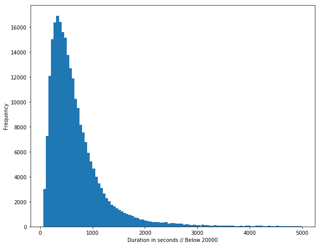

```python
#Code: for duration in seconds above 5000
df.query('duration_sec < 5000')['duration_sec'].plot.hist(bins = 100 ,
                                                          figsize = (10 , 8)).set(xlabel = 'Duration in seconds // Below 20000')
plt.title("Duration Seconds",fontsize=18)
plt.show()
```

## Duration Seconds by Users

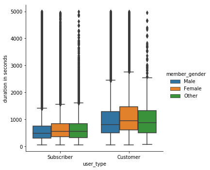

```python
#code: Boxplot graph
g = sb.catplot(x="user_type", y="duration_sec", hue="member_gender", kind="box",
                  data=df.query('duration_sec < 5000'))
g.set_xlabels('user_type')
g.set_ylabels('duration in seconds')
plt.title("Duration Seconds by Users",fontsize=18)
plt.show()
```

## Target Audience

> Target Audience based of the exploration above, knowing more about the users if the they are subscribers or customers, where subscribers tend generate more revenue with a good start knowing people hitting their 30's really love biking. Hence, the target audience where digital marketing can also increase number of subscribers.

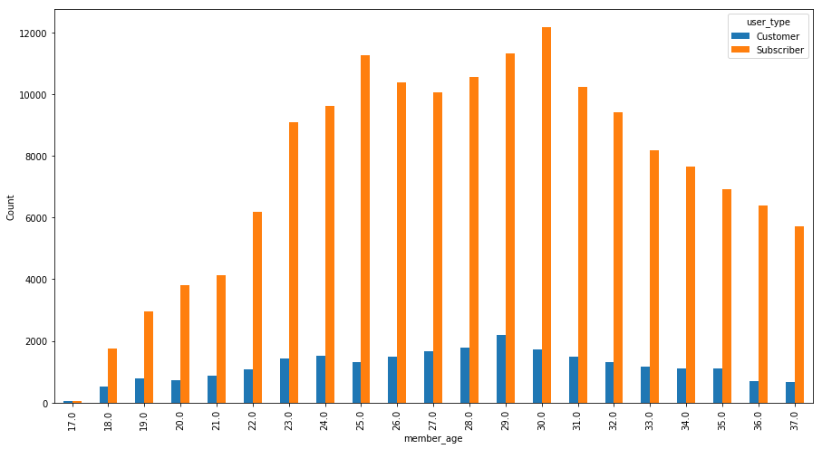

```python
#Code: Barchat
pd.crosstab(df.query('member_birth_year > 1980')['member_age'] ,
            df.query('member_birth_year > 1980')['user_type']).plot(kind = 'bar' , figsize = (15 ,8))
plt.xlabel('member_age')
plt.ylabel('Count')
plt.title("Target Audience",fontsize=18)
plt.show()
```